# Examined Algorithms - Bayesian Estimation and the Histogram Approximation

probability

experiments

bayesian-AB-tests

histogram-trick

Author

Nathaniel Forde

Published

August 15, 2022

Imagine you’re pretty confident of your recent bet. All the other gamblers at the table have taken the other side of the bet. Just for fun, assume all other gamblers in the casino have bet against you. The game is in the first quarter and things are looking good, but how do you evaluate now whether you should hedge your bets before final quarter is called? This kind of scenario is typical in an imbalanced A/B test where we haven’t randomised the samples, and we’re letting it ride based entirely on vibes. Maybe you’ve released a change to production but only exposed two clients to the new changes. How do you evaluate the impact of your change?

# Bayesian A/B testing in an imperfect World

You have at least 2 problems here. On the one hand you’re trusting your prior belief and small data. On the other side is a huge mass of data. Moving past the fear, the huge data is a problem more of implementation than one of principle, since Bayesian inference tends to scale poorly with massive amounts of data. The first problem is one of principle.

How do we make sound inference without trying to control for confounders through randomisation? But assume your hands are tied, you can’t guarantee perfect randomness in selection criteria. You still have to make a call with limited information. Perhaps you’d like to apply simple Bootstrapping estimation of the uncertainty in the parameters, but can’t because of the low volumes of data on one branch.

There are now two benefits to going with a Bayesian methodology here. One is the flexibility of the modelling paradigm it offers and the second primary feature is the ability to inject our prior information to weigh against the data on the undersampled arm of our experiment. This is a form of principled inference based on knowledge of the situation. No form of inference guarantees perfectly correct results. How to do we address the second problem? Bayesianism doesn’t scale, right!?

## Mixture Models and Histogram Trick

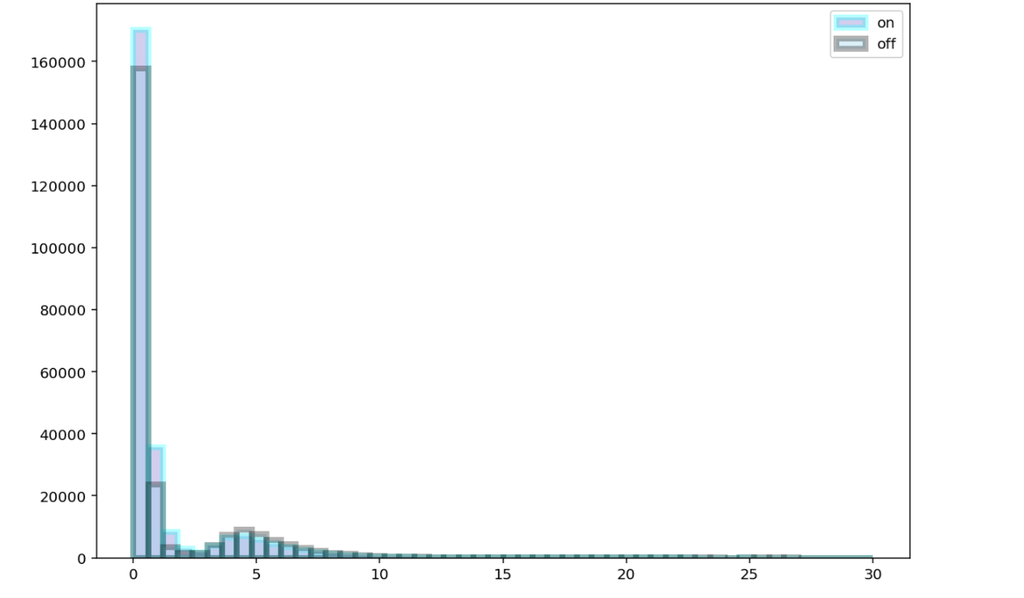

bi_modal

### What kind of Model?

Often we observe a data generating process which is likely the combination of a number of distinct processes. The overall distribution is known as a mixture distribution and there are some tools in the Bayesian workflow to help identify the manner in which these distinct processes are combined and the relative weight we should ascribe to each.

Bayesian modelling in general requires extensive MCMC simulation and as the data scales up there is a proportional impact on the fitting time of the model. This becomes infeasible with large data such as website performance data measured in the nanosecond. However there is a neat treat to approximate learning the Bayesian posterior from massive data - as discussed here:

> Want to run Bayesian A/B tests at serious scale? Check out how [@ferrine96](https://twitter.com/ferrine96?ref_src=twsrc%5Etfw) and I did this for one of [@pymc_labs](https://twitter.com/pymc_labs?ref_src=twsrc%5Etfw)' clients.https://t.co/cJJPH7X0UZ [pic.twitter.com/BnLNtENzam](https://t.co/BnLNtENzam)

> — Dr Benjamin Vincent (@inferencelab) [August 12, 2022](https://twitter.com/inferencelab/status/1558046236451774466?ref_src=twsrc%5Etfw)

Instead of learning from the raw data, we learn from a histogram approximation which buckets our data into n-quantiles (however many required) and weights the observations to be drawn from that quantile in proportion to the number of observations seen in the raw data within that range.

### Testing the Histogram Trick on a Mixture Model

Drum up some fake data

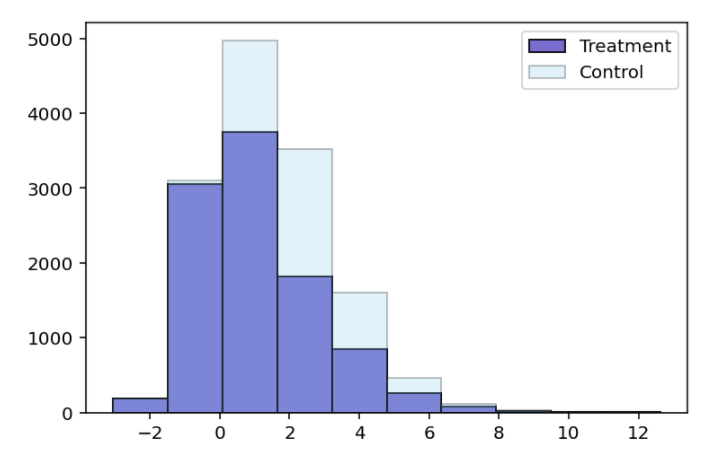

fake

```python
sample = pd.Series(np.random.normal(0, .8, 6000))
sample = pd.concat([sample, pd.Series(np.random.gumbel(2, 1.2, 4000))])

sample1 = pd.Series(np.random.normal(0.3, .8, 6000))
sample1 = pd.concat([sample, pd.Series(np.random.gumbel(1.8, 1.2, 4000))])

fig, ax = plt.subplots()
ax.hist(sample, alpha=0.9, edgecolor='black', color='slateblue', label='Treatment')
ax.hist(sample1, alpha=0.25, edgecolor='black', color='skyblue', label='Control')
ax.legend()
```

First we’ll estimate the model using the standard PYMC mcmc sampling method and then we’ll show how to do the same using the histogram trick. After seeing that the histogram trick preserves sound inference we’ll apply it to our big data problem and estimate our bi-modal loading time distribution.

### The Standard Bayesian Approach

We fit a Normal and Gumbel mixture distribution for our fake data using the standard method

```python
with pm.Model() as model_mix:
    # First set of priors for our treatment group
    w = pm.Dirichlet('w', a=np.array([1, 1]))  # 2 mixture weights
    mu = pm.Normal("mu", 0, 1)
    mu1 = pm.Normal("mu1", 2, 1)
    sd = pm.HalfNormal('sd', 1)
    sd1 = pm.HalfNormal('sd1', 1)

    components = [
        pm.Normal.dist(mu=mu, sigma=sd),
        pm.Gumbel.dist(mu=mu1, beta=sd1),
    ]

    # Second set of priors for our Control group
    w1 = pm.Dirichlet('w1', a=np.array([1, 1]))  # 2 mixture weights
    m = pm.Normal("m", 0, 1)
    m1 = pm.Normal("m1", 2, 1)
    s = pm.HalfNormal('s', 1)
    s1 = pm.HalfNormal('s1', 1)

    components1 = [
        pm.Normal.dist(mu=m, sigma=s),
        pm.Gumbel.dist(mu=m1, beta=s1),
    ]

    # Likelihood for our Treatment group
    mix = pm.Mixture('mix', w=w, comp_dists=components,
        observed=np.array(sample))

    # Likelihood for our Control group
    mix1 = pm.Mixture('mix1', w=w1, comp_dists=components1,
        observed=np.array(sample1))

    idata_mix = pm.sample(draws=1000, cores=1)
    idata_mix.extend(pm.sample_posterior_predictive(idata_mix))
```

### The Histogram Trick

Now when we wish to fit the same model using the Histogram trick, the code is similar but we change the likelihoods:

```python
    pot = pmx.distributions.histogram_approximation(
        "pot", pm.Mixture.dist(w=w, comp_dists=components),
        observed=np.array(sample), n_quantiles=1000)

    pot = pmx.distributions.histogram_approximation(
        "pot1", pm.Mixture.dist(w=w1, comp_dists=components1),
        observed=np.array(sample1), n_quantiles=1000)

    idata_mix_approx = pm.sample(draws=5000, cores=1)
```

Under the hood the histogram trick is a pm.Potential, and as such the implementation cannot make use of the standard posterior predictive sampling. But we can do a manual work-around to achieve the same results, by sampling from the posterior draws on the parameters which determine the shape of our model. Even better it fits *very* fast!!

```python
## Extract uncertainty in parameters from our posterior
gen_df = pd.DataFrame({'mu': idata_mix_approx.stack(sample=["chain", "draw"]).posterior['mu'],
                'sd': idata_mix_approx.stack(sample=["chain", "draw"]).posterior['sd'],
                 'mu1': idata_mix_approx.stack(sample=["chain", "draw"]).posterior['mu1'],
                  'sd1': idata_mix_approx.stack(sample=["chain", "draw"]).posterior['sd1'],
                  'm': idata_mix_approx.stack(sample=["chain", "draw"]).posterior['m'],
                's': idata_mix_approx.stack(sample=["chain", "draw"]).posterior['s'],
                 'm1': idata_mix_approx.stack(sample=["chain", "draw"]).posterior['m1'],
                  's1': idata_mix_approx.stack(sample=["chain", "draw"]).posterior['s1']
                  })

## Generate samples from each mixture component for treatment and control groups
gen_df['y_T'] = gen_df.apply(lambda x: np.random.normal(x['mu'], x['sd'], 1)[0], axis=1)
gen_df['y1_T'] = gen_df.apply(lambda x: np.random.gumbel(x['mu1'], x['sd1'], 1)[0], axis=1)
gen_df['y_C'] = gen_df.apply(lambda x: np.random.normal(x['m'], x['s'], 1)[0], axis=1)
gen_df['y1_C'] = gen_df.apply(lambda x: np.random.gumbel(x['m1'], x['s1'], 1)[0], axis=1)

## Extract expected weights from each component
weights_T = idata_mix_approx.stack(sample=['chain', 'draw']).posterior['w'].mean(axis=1).to_dataframe()
weights_C = idata_mix_approx.stack(sample=['chain', 'draw']).posterior['w1'].mean(axis=1).to_dataframe()

## Combine to recover a predictive distribution for our data
mix_posterior_y_T = pd.concat([gen_df['y_T'].sample(frac=weights_T['w'][0]),
                           gen_df['y1_T'].sample(frac=weights_T['w'][1])])

mix_posterior_y_C = pd.concat([gen_df['y_C'].sample(frac=weights_C['w1'][0]),
                           gen_df['y1_C'].sample(frac=weights_C['w1'][1])])
```

### Plotting the Fits

With these quantities in place we can plot the predictions of both models against the distribution of the raw data.

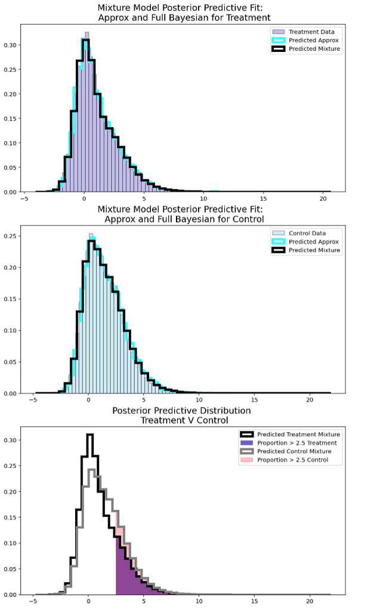

fake

```python
fig, axs = plt.subplots(3, 1, figsize=(10, 18))
axs = axs.flatten()
axs[0].hist(sample, density=True, alpha=0.4, label='Treatment Data', color='slateblue', bins=50, edgecolor='black')
axs[0].hist(mix_posterior_y_T, density=True, label='Predicted Approx', histtype='step', linewidth=4, color='cyan', bins=50)
axs[0].hist(idata_mix.stack(sample=['chain', 'draw']).posterior_predictive['mix'].to_dataframe()['mix'], density=True, label='Predicted Mixture', histtype='step', linewidth=4, color='black', bins=50)
axs[0].legend()
axs[0].set_title("Mixture Model Posterior Predictive Fit:  \n Approx and Full Bayesian for Treatment", fontsize=15)
axs[1].hist(sample1, density=True, alpha=0.4, label='Control Data',edgecolor='black',
color='skyblue', bins=50)
axs[1].hist(mix_posterior_y_C, density=True, label='Predicted Approx', histtype='step', linewidth=4, color='cyan', bins=50)
axs[1].hist(idata_mix.stack(sample=['chain', 'draw']).posterior_predictive['mix1'].to_dataframe()['mix1'], density=True, label='Predicted Mixture', histtype='step', linewidth=4, color='black', bins=50)
axs[1].legend()
axs[1].set_title("Mixture Model Posterior Predictive Fit:  \n Approx and Full Bayesian for Control", fontsize=15)

xs, ys, patches = axs[2].hist(idata_mix.stack(sample=['chain', 'draw']).posterior_predictive['mix'].to_dataframe()['mix'], density=True, label='Predicted Treatment Mixture', histtype='step', linewidth=4, color='black', bins=50)
axs[2].axvspan(2.5, 10, clip_path=patches[0], color='slateblue', label='Proportion > 2.5 Treatment')

xs1, ys1, patches1 =axs[2].hist(idata_mix.stack(sample=['chain', 'draw']).posterior_predictive['mix1'].to_dataframe()['mix1'], density=True, label='Predicted Control Mixture', histtype='step', linewidth=4, color='grey', bins=50)
axs[2].axvspan(2.5, 10, clip_path=patches1[0], color='red', alpha=0.25, label='Proportion > 2.5 Control')
axs[2].set_title("Posterior Predictive Distribution \n Treatment V Control", fontsize=15)
axs[2].legend();
```

Here we can see how the histogram trick properly captures the shape of the distribution as well as the model estimated using the standard likelihood.

## Do we Push to Production?

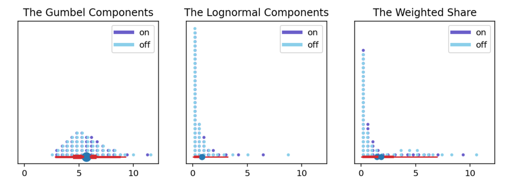

fake

We can also now quantify what proportion of the mixture distribution has shifted from the Gumbel component to the Lognormal component of the distribution, and hence how healthy our loading time distribution is predicted to be if we apply the treatment. We can formulate more precise measures of effect using the estimated mixture posterior distributions, but these cursory plots are at least directionally positive.

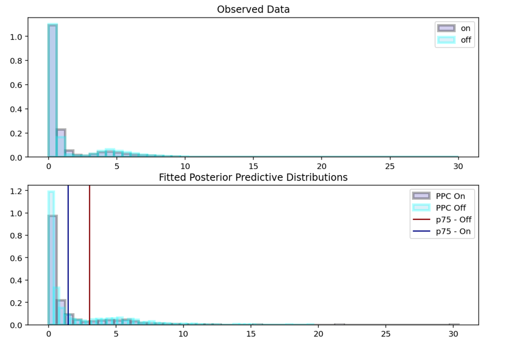

fake

It looks like we should make our change and hold our nerve! If we need to make a call now the data we have suggests we should!

## Conclusion

We’ve seen here a concrete example of some innovative tooling that the PYMC team is developing to help scale Bayesian inference in industry. I hope i’ve given a clean example of you might use this form of inference to interrogate questions of improvemnt in imbalanced A/B style experiemnts. Feedback or pushback welcome!?